# Testing Hardy–Weinberg proportions

Population Genetics Practical 8: Fitted expectations, sparse counts and exact inference

## Learning objectives

Fit HWE expectations from genotype counts; explain the chi-square test’s degrees of freedom; compare approximate and exact inference; state an exact test’s two-sided convention; and interpret rejection without claiming a biological cause.

Read after Practical 2, alongside the slides on HWE testing and the chi-square test. Practical 3 supplies the distinction between structure, mating and inbreeding. All inputs here are hypothetical, and all calculations use base R.

## 1. State the sampling model and null hypothesis

We study one diploid biallelic autosomal locus with accurately called AA, AB and BB genotypes. The sample consists of independent individuals from a declared population, without outcome-dependent ascertainment. Missing calls are excluded and their denominator reported. Relatives, pooled populations, uncertain genotype calls or sex-linked inheritance require a different model or analysis.

The null is that genotype probabilities follow $p_A^2,2p_A(1-p_A),(1-p_A)^2$ for some population allele frequency. A test compares counts with this model; it does not test every mechanism associated with random mating or identify why a departure occurred.

**Show R code**

```r
validate_counts <- function(counts) {
  stopifnot(is.numeric(counts),length(counts)==3,!is.null(names(counts)),
    !anyDuplicated(names(counts)),setequal(names(counts),c("AA","AB","BB")),
    all(is.finite(counts)),all(counts>=0),all(counts==floor(counts)),
    sum(counts)>0,sum(counts)<=1000)
  counts[c("AA","AB","BB")]
}
hwe_summary <- function(counts) {
  counts <- validate_counts(counts)
  n <- sum(counts)
  pA <- (2*counts["AA"]+counts["AB"])/(2*n)
  expected <- n*c(AA=unname(pA)^2,AB=2*unname(pA)*(1-unname(pA)),
                   BB=(1-unname(pA))^2)
  list(counts=counts,n=n,pA=unname(pA),expected=expected)
}
counts <- c(AA=48,AB=36,BB=16)
s <- hwe_summary(counts)
stopifnot(s$n==100,abs(s$pA-.66)<1e-12,
          max(abs(s$expected-c(43.56,44.88,11.56)))<1e-12)
knitr::kable(data.frame(genotype=names(counts),observed=counts,
                       fitted_expected=s$expected),digits=2,row.names=FALSE)
```

| genotype | observed | fitted_expected |
| --- | --- | --- |
| AA | 48 | 43.56 |
| AB | 36 | 44.88 |
| BB | 16 | 11.56 |

The helper requires named nonnegative integer counts and caps this teaching example at 1,000 individuals. It is not a production testing interface. Fractional expected counts are valid; fractional observed genotype counts are not supported here.

## 2. Calculate a chi-square approximation

For positive fitted expectations,

$$X^2=\sum_{g\in\{AA,AB,BB\}}\frac{(O_g-E_g)^2}{E_g}.$$

Three category counts have two free proportions because they sum to the sample size. Estimating one allele-frequency parameter from the same sample leaves $3-1-1=1$ degree of freedom. This is an asymptotic approximation, particularly questionable when an expected genotype count is small.

**Show R code**

```r
hwe_chisq <- function(counts) {
  s <- hwe_summary(counts)
  if(any(s$expected==0)) {
    return(c(statistic=NA_real_,df=NA_real_,p_value=NA_real_))
  }
  statistic <- sum((s$counts-s$expected)^2/s$expected)
  c(statistic=unname(statistic),df=1,
    p_value=pchisq(statistic,df=1,lower.tail=FALSE))
}
chi <- hwe_chisq(counts)
chi
```

```
 statistic         df    p_value
3.91489605 1.00000000 0.04785998
```

**Show R code**

```r
# A generic goodness-of-fit call treats supplied probabilities as fixed.
generic <- suppressWarnings(chisq.test(counts,p=s$expected/s$n))
stopifnot(abs(unname(generic$statistic)-chi["statistic"])<1e-12,
          unname(generic$parameter)==2)
```

The generic call gives the same statistic but uses two degrees of freedom, because it does not know that those probabilities were fitted from these counts. Its default p-value therefore does not implement this fitted HWE test. No continuity correction is used in our calculation.

**Question 1.** What if allele frequency were genuinely specified before sampling?

**Suggested answer**

Then the three genotype probabilities would be fully specified, with two degrees of freedom in a regular goodness-of-fit approximation. That tests a particular allele frequency as well as HWE proportions. It is a different null from fitting allele frequency within the current sample.

## 3. Enumerate an exact conditional distribution

Condition on sample size $n$ and the observed number $K$ of B copies. For a possible heterozygote count $h$,

$$n_{BB}=(K-h)/2,\qquad n_{AA}=n-h-n_{BB}.$$

Only nonnegative integer configurations are allowed. Under the independent-individual HWE model, their conditional probabilities are

$$P(h\mid n,K)=
\frac{n!\,2^h}{n_{AA}!\,h!\,n_{BB}!\,\binom{2n}{K}}.$$

The factor $2^h$ accounts for the two orders of unlike alleles in each heterozygote. Conditioning removes the unknown allele-frequency parameter. We define a **probability-ordered two-sided p-value** as the sum of probabilities of configurations no more probable than the observed configuration, including ties. This is not a mid-p test or a doubled one-sided tail. For exact-test conventions and efficient algorithms, see [Wigginton, Cutler and Abecasis (2005)](https://pmc.ncbi.nlm.nih.gov/articles/PMC1199378/).

**Show R code**

```r
hwe_exact <- function(counts) {
  counts <- validate_counts(counts)
  n <- sum(counts); K <- unname(counts["AB"]+2*counts["BB"])
  h <- seq.int(K %% 2,min(K,2*n-K),by=2)
  BB <- (K-h)/2; AA <- n-h-BB
  log_probability <- lgamma(n+1)+h*log(2)-lgamma(AA+1)-
    lgamma(h+1)-lgamma(BB+1)-lchoose(2*n,K)
  probability <- exp(log_probability)
  stopifnot(abs(sum(probability)-1)<1e-10)
  probability <- probability/sum(probability) # Floating-point normalization.
  observed <- match(unname(counts["AB"]),h)
  included <- log_probability<=log_probability[observed]+1e-10
  p_value <- min(1,sum(probability[included]))
  list(p_value=p_value,n=n,B_copies=K,
       distribution=data.frame(AA=AA,AB=h,BB=BB,probability=probability,
                               included_in_p_value=included))
}
exact <- hwe_exact(counts)
exact$p_value
```

```
[1] 0.0476633
```

**Show R code**

```r
knitr::kable(exact$distribution,digits=5,row.names=FALSE)
```

| AA | AB | BB | probability | included_in_p_value |
| --- | --- | --- | --- | --- |
| 66 | 0 | 34 | 0.00000 | TRUE |
| 65 | 2 | 33 | 0.00000 | TRUE |
| 64 | 4 | 32 | 0.00000 | TRUE |
| 63 | 6 | 31 | 0.00000 | TRUE |
| 62 | 8 | 30 | 0.00000 | TRUE |
| 61 | 10 | 29 | 0.00000 | TRUE |
| 60 | 12 | 28 | 0.00000 | TRUE |
| 59 | 14 | 27 | 0.00000 | TRUE |
| 58 | 16 | 26 | 0.00000 | TRUE |
| 57 | 18 | 25 | 0.00000 | TRUE |
| 56 | 20 | 24 | 0.00000 | TRUE |
| 55 | 22 | 23 | 0.00000 | TRUE |
| 54 | 24 | 22 | 0.00000 | TRUE |
| 53 | 26 | 21 | 0.00003 | TRUE |
| 52 | 28 | 20 | 0.00015 | TRUE |
| 51 | 30 | 19 | 0.00070 | TRUE |
| 50 | 32 | 18 | 0.00275 | TRUE |
| 49 | 34 | 17 | 0.00883 | TRUE |
| 48 | 36 | 16 | 0.02334 | TRUE |
| 47 | 38 | 15 | 0.05100 | FALSE |
| 46 | 40 | 14 | 0.09219 | FALSE |
| 45 | 42 | 13 | 0.13791 | FALSE |
| 44 | 44 | 12 | 0.17057 | FALSE |
| 43 | 46 | 11 | 0.17403 | FALSE |
| 42 | 48 | 10 | 0.14595 | FALSE |
| 41 | 50 | 9 | 0.10008 | FALSE |
| 40 | 52 | 8 | 0.05570 | FALSE |
| 39 | 54 | 7 | 0.02491 | FALSE |
| 38 | 56 | 6 | 0.00883 | TRUE |
| 37 | 58 | 5 | 0.00244 | TRUE |
| 36 | 60 | 4 | 0.00051 | TRUE |
| 35 | 62 | 3 | 0.00008 | TRUE |
| 34 | 64 | 2 | 0.00001 | TRUE |
| 33 | 66 | 1 | 0.00000 | TRUE |
| 32 | 68 | 0 | 0.00000 | TRUE |

The log-factorial calculation avoids direct factorial overflow. Enumeration is intentionally small and transparent; no package implementation is copied or added.

### Check against allele-position enumeration

For five individuals and four B copies, enumerate all choices of four positions among ten labelled gene-copy positions. Each choice is equally likely conditional on the allele count. Pair adjacent positions to recover genotypes and compare the heterozygote distribution.

**Show R code**

```r
small <- hwe_exact(c(AA=2,AB=2,BB=1))
positions <- combn(10,4)
heterozygotes <- apply(positions,2,function(chosen) {
  alleles <- integer(10); alleles[chosen] <- 1L
  dosage <- colSums(matrix(alleles,nrow=2))
  sum(dosage==1)
})
frequency <- table(factor(heterozygotes,levels=small$distribution$AB))/ncol(positions)
stopifnot(max(abs(as.numeric(frequency)-small$distribution$probability))<1e-12,
          small$p_value==1)
knitr::kable(small$distribution,digits=4,row.names=FALSE)
```

| AA | AB | BB | probability | included_in_p_value |
| --- | --- | --- | --- | --- |
| 3 | 0 | 2 | 0.0476 | TRUE |
| 2 | 2 | 1 | 0.5714 | TRUE |
| 1 | 4 | 0 | 0.3810 | TRUE |

This checks the conditional distribution independently of the log-factorial formula. It does not verify sampling assumptions in a real dataset.

## 4. Compare dense, sparse and monomorphic counts

**Show R code**

```r
examples <- list(Moderate=c(AA=48,AB=36,BB=16),
                 Sparse=c(AA=8,AB=1,BB=1),
                 Monomorphic=c(AA=10,AB=0,BB=0))
comparison <- do.call(rbind,lapply(names(examples),function(label) {
  counts <- examples[[label]]; s <- hwe_summary(counts)
  data.frame(example=label,n=s$n,min_expected=min(s$expected),
    chi_square_p=unname(hwe_chisq(counts)["p_value"]),
    exact_p=hwe_exact(counts)$p_value)
}))
stopifnot(abs(comparison$exact_p[comparison$example=="Sparse"]-3/19)<1e-12,
          comparison$exact_p[comparison$example=="Monomorphic"]==1)
knitr::kable(comparison,digits=4,row.names=FALSE)
```

| example | n | min_expected | chi_square_p | exact_p |
| --- | --- | --- | --- | --- |
| Moderate | 100 | 11.560 | 0.0479 | 0.0477 |
| Sparse | 10 | 0.225 | 0.0546 | 0.1579 |
| Monomorphic | 10 | 0.000 | NA | 1.0000 |

The sparse example has a fitted minor-homozygote expectation below one, and the approximate and exact p-values differ. No universal expected-count rule guarantees approximation quality. In the monomorphic sample the conditional distribution has one configuration and p-value one; the fitted chi-square calculation is undefined. This reflects no conditional information about departure, not proof that the population satisfies HWE.

**Show R code**

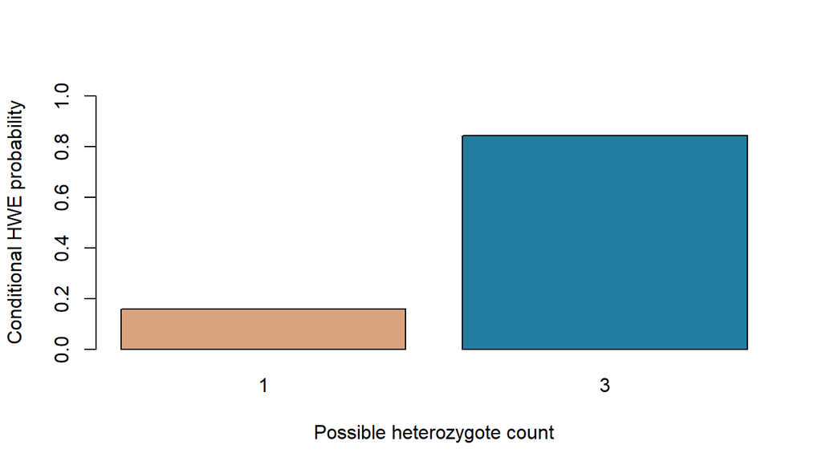

Figure 1: Only two genotype configurations are possible for ten individuals with three B copies. The observed sparse configuration has one heterozygote.

```r
sparse <- hwe_exact(examples$Sparse)
barplot(setNames(sparse$distribution$probability,sparse$distribution$AB),
        col=c("#D8A47F","#247BA0"),xlab="Possible heterozygote count",
        ylab="Conditional HWE probability",ylim=c(0,1))
```

### Discrete p-values and attainable rejection

An exact probability-ordered test can have only a few attainable p-values. Evaluate the test on every configuration for this sparse conditional distribution. Its null rejection probability at level 0.05 is zero because neither configuration reaches that threshold.

**Show R code**

```r
support <- sparse$distribution
p_values <- vapply(seq_len(nrow(support)),function(i)
  hwe_exact(c(AA=support$AA[i],AB=support$AB[i],BB=support$BB[i]))$p_value,
  numeric(1))
alpha <- .05
conditional_rejection_probability <- sum(support$probability[p_values<=alpha])
stopifnot(conditional_rejection_probability==0)
knitr::kable(data.frame(support[,1:4],p_value=p_values),digits=4,row.names=FALSE)
```

| AA | AB | BB | probability | p_value |
| --- | --- | --- | --- | --- |
| 8 | 1 | 1 | 0.1579 | 0.1579 |
| 7 | 3 | 0 | 0.8421 | 1.0000 |

Non-rejection is compatible with limited power. The test’s exactness is conditional on its sampling model; it does not repair population pooling, relatives or erroneous calls.

## 5. Interpret a departure without naming its cause

Population structure, nonrandom mating, selection or technical calling errors can produce departures from the tested proportions. Which mechanism applies needs additional information. Sampling relatives can also invalidate the independent-individual null distribution even when marginal genotype proportions match.

A hypothetical population mixture has two equal groups with HWE counts corresponding to allele frequencies 0.9 and 0.1. Within-group counts fit their models exactly, but pooled counts do not fit the random-union model at frequency 0.5.

**Show R code**

```r
population1 <- c(AA=81,AB=18,BB=1)
population2 <- c(AA=1,AB=18,BB=81)
pooled <- population1+population2
stopifnot(hwe_chisq(population1)["statistic"]<1e-25,
          hwe_chisq(population2)["statistic"]<1e-25,
          hwe_exact(pooled)$p_value<.05)
knitr::kable(data.frame(group=c("Population 1","Population 2","Pooled"),
  exact_p=c(hwe_exact(population1)$p_value,hwe_exact(population2)$p_value,
            hwe_exact(pooled)$p_value)),digits=5,row.names=FALSE)
```

| group | exact_p |
| --- | --- |
| Population 1 | 1 |
| Population 2 | 1 |
| Pooled | 0 |

These supplied counts illustrate pooling; they are not independent simulated draws or evidence about real mating. A low pooled p-value would not identify individual pedigree inbreeding. Conversely, a high p-value is not the posterior probability that HWE is true.

## Exercises

1. Reverse AA and BB counts and verify both test results stay unchanged.
2. Multiply the moderate counts by five. Explain why identical genotype proportions need not give the same p-value.
3. State what must be reported before using HWE test results as a marker-quality filter across many loci.

**Suggested solutions**

**Show R code**

```r
counts <- examples$Moderate
reversed <- setNames(rev(counts),names(counts))
stopifnot(abs(hwe_exact(reversed)$p_value-hwe_exact(counts)$p_value)<1e-12,
  abs(hwe_chisq(reversed)["statistic"]-hwe_chisq(counts)["statistic"])<1e-12,
  abs(hwe_chisq(5*counts)["statistic"]-5*hwe_chisq(counts)["statistic"])<1e-12)
```

At fixed proportions the chi-square statistic scales with sample size, so more observations can provide stronger evidence against the same departure. Report the population and locus definitions, called sample size, genotype counts, missingness, relatedness/ascertainment rules, test convention and threshold. For many markers, specify the multiple-testing or quality-control policy and investigate technical and biological explanations. A threshold alone is not a universal reason to discard every departing locus.

## App and package connections

The existing HWE test Shiny source is available for optional local exploration with its existing dependencies; this practical does not modify or qualify it. `gpop` owns population summaries and estimator assumptions. The base-R enumeration here is a teaching calculation, not an exported `gpop` method.

Return to population structure and inbreeding for interpretation or the [course map](https://psoerensen.github.io/quantitative-genetics/tutorials/course_map.html) for teaching routes. For a worked association analysis with covariates, multiple testing and cautious causal interpretation, continue to [QG Practical 13](https://psoerensen.github.io/quantitative-genetics/tutorials/association_mapping.html).